# Quamichan Lake

##### Boron Total (fl. conc.)

✓

[BC Aquatic Life Guideline](https://www2.gov.bc.ca/gov/content/environment/air-land-water/water/water-quality/water-quality-guidelines/approved-water-quality-guidelines) · Long-term chronic (Upper Limit) Aquatic Life - Freshwater

≤1.2 mg/L

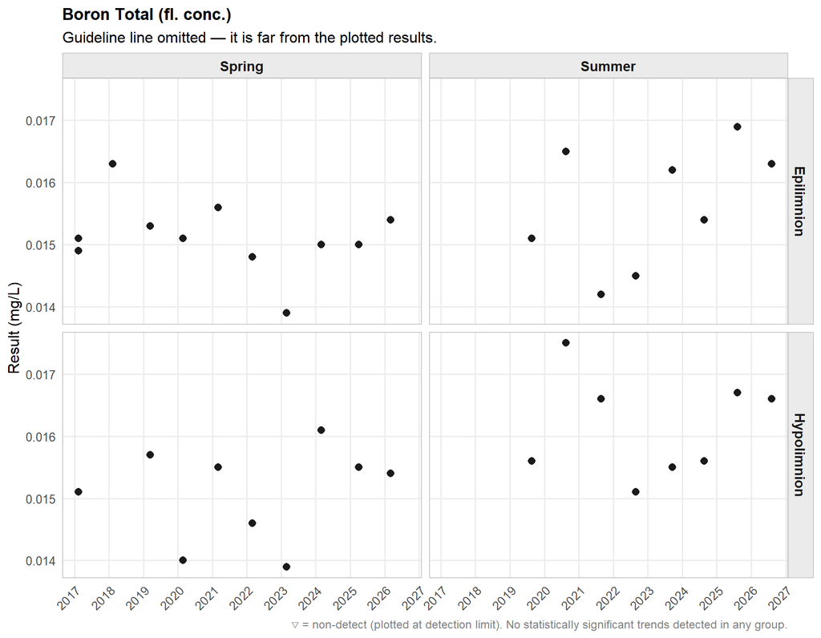

**▶ Summary Statistics Table**

**Quamichan Lake**

Boron Total (fl. conc.) (mg/L)

| N | Min<sup>1</sup> | 10th %ile | Median | Mean | 90th %ile | Max |
| --- | --- | --- | --- | --- | --- | --- |
| Hypolimnion — Summer |  |  |  |  |  |  |
| 8 | 0.0151 | 0.0154 | 0.0161 | 0.0162 | 0.0169 | 0.0175 |
| Hypolimnion — Spring |  |  |  |  |  |  |
| 9 | 0.0139 | 0.014 | 0.0154 | 0.0151 | 0.0158 | 0.0161 |
| Epilimnion — Summer |  |  |  |  |  |  |
| 8 | 0.0142 | 0.0144 | 0.0158 | 0.0156 | 0.0166 | 0.0169 |
| Epilimnion — Spring |  |  |  |  |  |  |
| 11 | 0.0139 | 0.0148 | 0.0151 | 0.0151 | 0.0156 | 0.0163 |

<sup>1</sup> < indicates non-detect; value shown is the detection limit.

##### Cadmium Total (fl. conc.)

—

No simple [BC Aquatic Life Guideline](https://www2.gov.bc.ca/gov/content?id=044DD64C7E24415D83D07430964113C9) available for this parameter

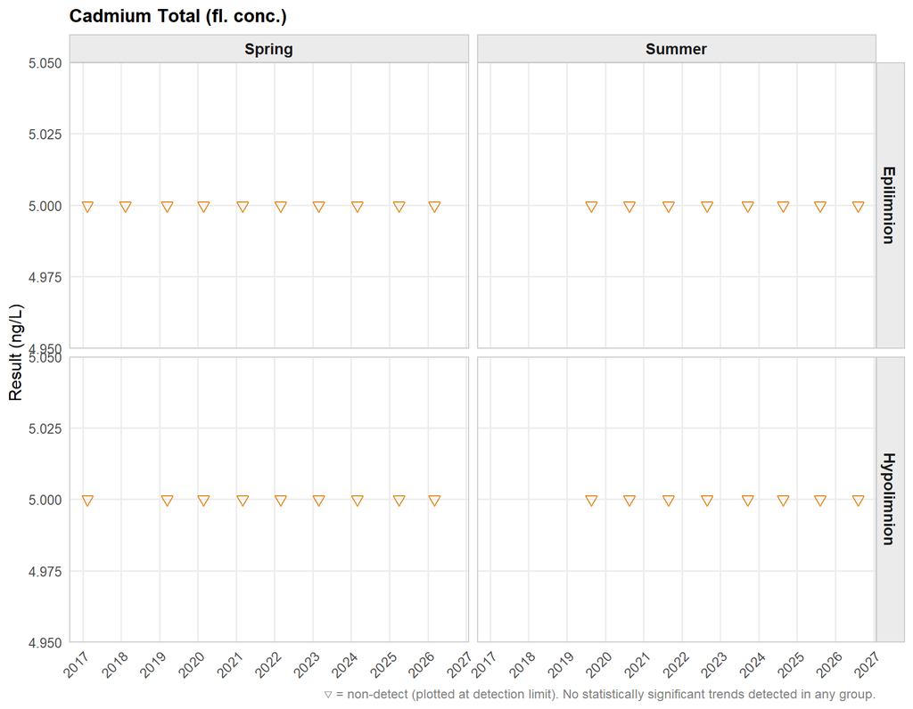

**▶ Summary Statistics Table**

**Quamichan Lake**

Cadmium Total (fl. conc.) (ng/L)

| N | Min<sup>1</sup> | 10th %ile | Median | Mean | 90th %ile | Max |
| --- | --- | --- | --- | --- | --- | --- |
| Hypolimnion — Summer |  |  |  |  |  |  |
| 8 | <5 | <5 | <5 | <5 | <5 | <5 |
| Hypolimnion — Spring |  |  |  |  |  |  |
| 9 | <5 | <5 | <5 | <5 | <5 | <5 |
| Epilimnion — Summer |  |  |  |  |  |  |
| 8 | <5 | <5 | <5 | <5 | <5 | <5 |
| Epilimnion — Spring |  |  |  |  |  |  |
| 11 | <5 | <5 | <5 | <5 | <5 | <5 |

<sup>1</sup> < indicates non-detect; value shown is the detection limit.

##### Calcium Total (fl. conc.)

—

No simple [BC Aquatic Life Guideline](https://www2.gov.bc.ca/gov/content?id=044DD64C7E24415D83D07430964113C9) available for this parameter

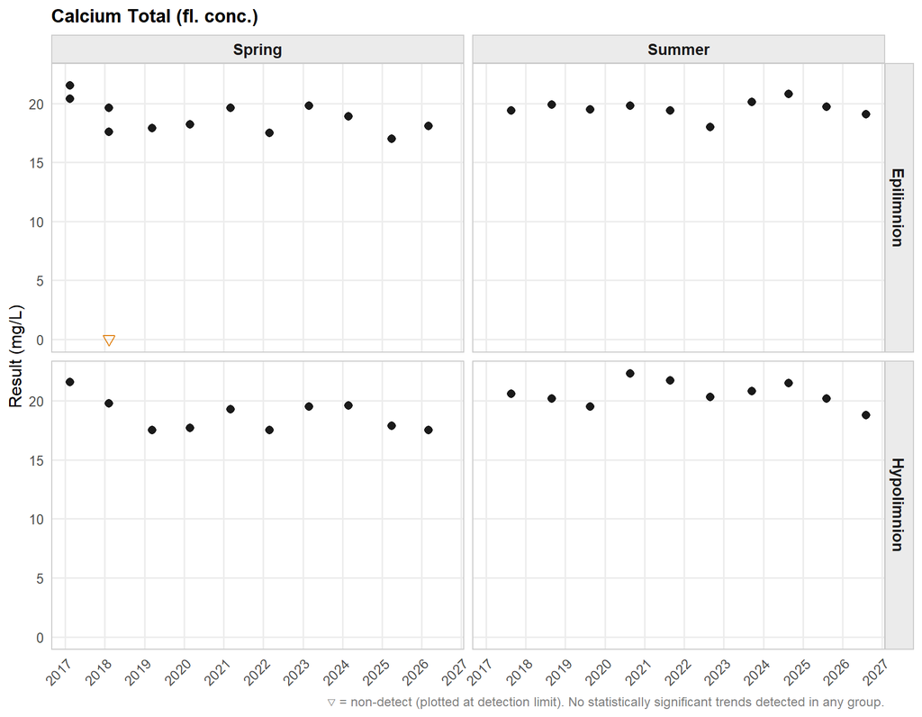

**▶ Summary Statistics Table**

**Quamichan Lake**

Calcium Total (fl. conc.) (mg/L)

| N | Min<sup>1</sup> | 10th %ile | Median | Mean | 90th %ile | Max |
| --- | --- | --- | --- | --- | --- | --- |
| Hypolimnion — Summer |  |  |  |  |  |  |
| 10 | 18.8 | 19.4 | 20.5 | 20.6 | 21.8 | 22.3 |
| Hypolimnion — Spring |  |  |  |  |  |  |
| 10 | 17.5 | 17.5 | 18.6 | 18.8 | 20 | 21.6 |
| Epilimnion — Summer |  |  |  |  |  |  |
| 10 | 18 | 19 | 19.6 | 19.6 | 20.2 | 20.8 |
| Epilimnion — Spring |  |  |  |  |  |  |
| 14 | <0.05 | 17.2 | 18.5 | 17.6 | 20.2 | 21.5 |

<sup>1</sup> < indicates non-detect; value shown is the detection limit.

##### Chromium Total (fl. conc.)

—

No simple [BC Aquatic Life Guideline](https://www2.gov.bc.ca/gov/content?id=044DD64C7E24415D83D07430964113C9) available for this parameter

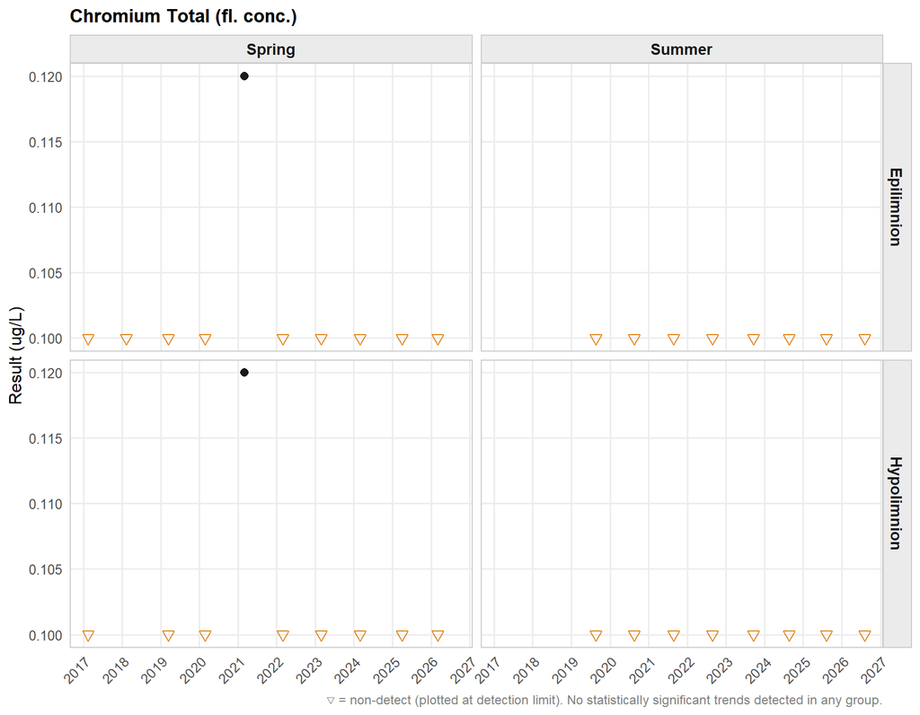

**▶ Summary Statistics Table**

**Quamichan Lake**

Chromium Total (fl. conc.) (ug/L)

| N | Min<sup>1</sup> | 10th %ile | Median | Mean | 90th %ile | Max |
| --- | --- | --- | --- | --- | --- | --- |
| Hypolimnion — Summer |  |  |  |  |  |  |
| 8 | <0.1 | <0.1 | <0.1 | <0.1 | <0.1 | <0.1 |
| Hypolimnion — Spring |  |  |  |  |  |  |
| 9 | <0.1 | <0.1 | <0.1 | 0.102 | 0.104 | 0.12 |
| Epilimnion — Summer |  |  |  |  |  |  |
| 8 | <0.1 | <0.1 | <0.1 | <0.1 | <0.1 | <0.1 |
| Epilimnion — Spring |  |  |  |  |  |  |
| 11 | <0.1 | <0.1 | <0.1 | 0.102 | <0.1 | 0.12 |

<sup>1</sup> < indicates non-detect; value shown is the detection limit.

##### Cobalt Total (fl. conc.)

—

No simple [BC Aquatic Life Guideline](https://www2.gov.bc.ca/gov/content?id=044DD64C7E24415D83D07430964113C9) available for this parameter

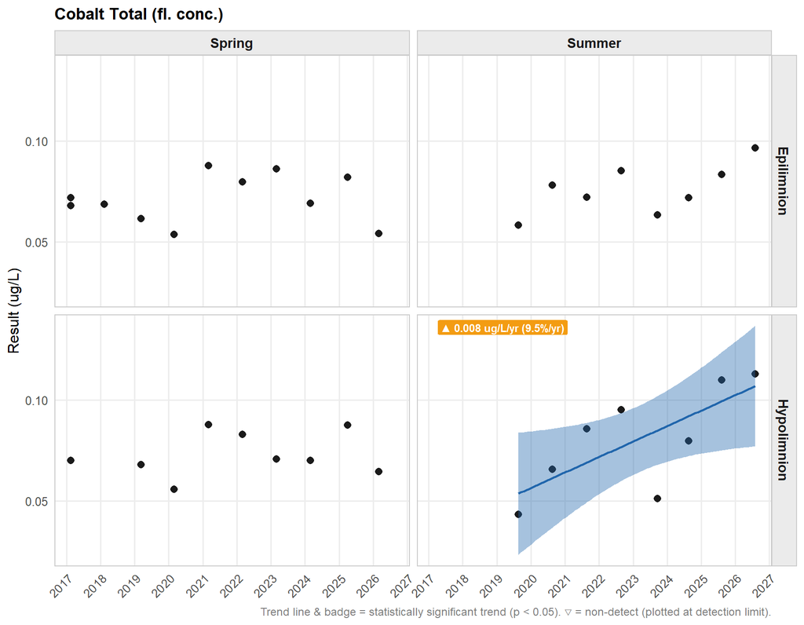

**▶ Summary Statistics Table**

**Quamichan Lake**

Cobalt Total (fl. conc.) (ug/L)

| N | Min<sup>1</sup> | 10th %ile | Median | Mean | 90th %ile | Max |
| --- | --- | --- | --- | --- | --- | --- |
| Hypolimnion — Summer |  |  |  |  |  |  |
| 8 | 0.0434 | 0.0489 | 0.0829 | 0.0806 | 0.111 | 0.113 |
| Hypolimnion — Spring |  |  |  |  |  |  |
| 9 | 0.0559 | 0.0628 | 0.0701 | 0.0731 | 0.0877 | 0.0879 |
| Epilimnion — Summer |  |  |  |  |  |  |
| 8 | 0.0583 | 0.0618 | 0.075 | 0.076 | 0.0885 | 0.0964 |
| Epilimnion — Spring |  |  |  |  |  |  |
| 11 | 0.0537 | 0.0541 | 0.069 | 0.0711 | 0.0861 | 0.0878 |

<sup>1</sup> < indicates non-detect; value shown is the detection limit.

##### Copper Total (fl. conc.)

—

No simple [BC Aquatic Life Guideline](https://www2.gov.bc.ca/gov/content?id=044DD64C7E24415D83D07430964113C9) available for this parameter

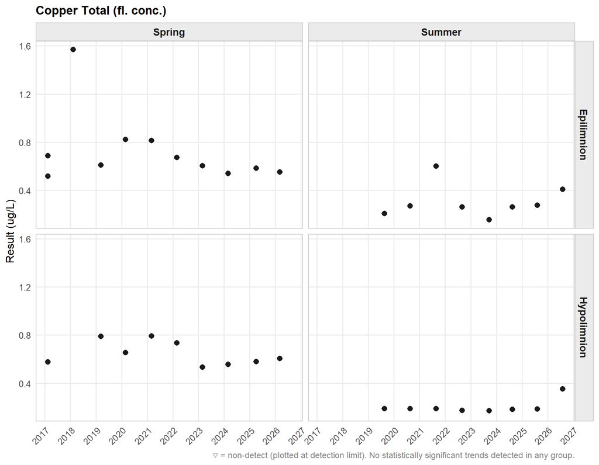

**▶ Summary Statistics Table**

**Quamichan Lake**

Copper Total (fl. conc.) (ug/L)

| N | Min<sup>1</sup> | 10th %ile | Median | Mean | 90th %ile | Max |
| --- | --- | --- | --- | --- | --- | --- |
| Hypolimnion — Summer |  |  |  |  |  |  |
| 8 | 0.171 | 0.174 | 0.186 | 0.204 | 0.239 | 0.353 |
| Hypolimnion — Spring |  |  |  |  |  |  |
| 9 | 0.533 | 0.553 | 0.606 | 0.647 | 0.79 | 0.792 |
| Epilimnion — Summer |  |  |  |  |  |  |
| 8 | 0.156 | 0.193 | 0.266 | 0.306 | 0.467 | 0.601 |
| Epilimnion — Spring |  |  |  |  |  |  |
| 11 | 0.519 | 0.542 | 0.609 | 0.725 | 0.822 | 1.57 |

<sup>1</sup> < indicates non-detect; value shown is the detection limit.

##### Iron Total (fl. conc.)

—

No simple [BC Aquatic Life Guideline](https://www2.gov.bc.ca/gov/content?id=044DD64C7E24415D83D07430964113C9) available for this parameter

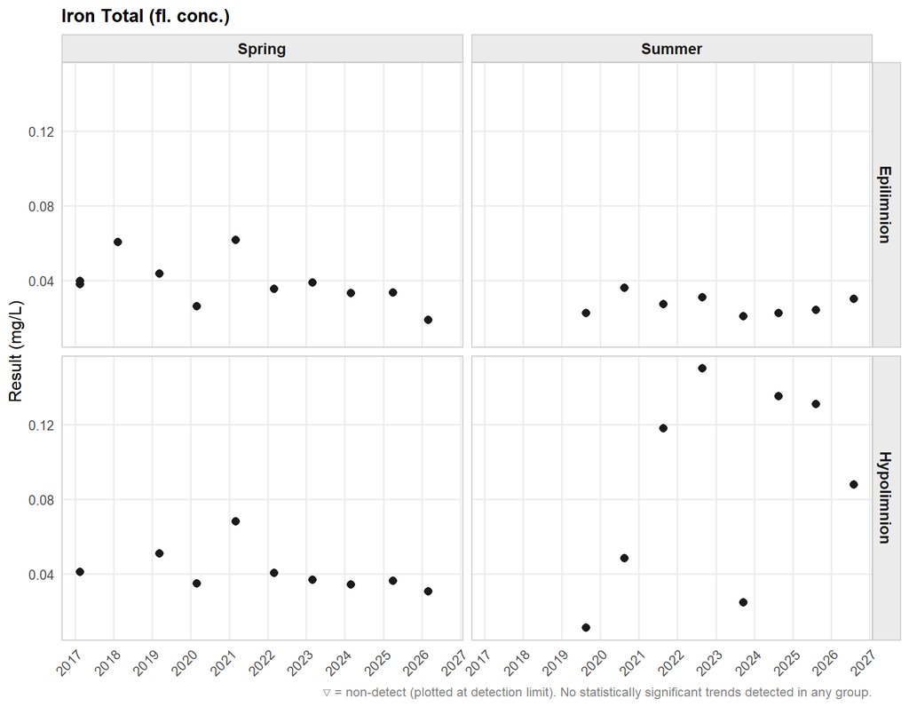

**▶ Summary Statistics Table**

**Quamichan Lake**

Iron Total (fl. conc.) (mg/L)

| N | Min<sup>1</sup> | 10th %ile | Median | Mean | 90th %ile | Max |
| --- | --- | --- | --- | --- | --- | --- |
| Hypolimnion — Summer |  |  |  |  |  |  |
| 8 | 0.0113 | 0.0207 | 0.103 | 0.0882 | 0.14 | 0.15 |
| Hypolimnion — Spring |  |  |  |  |  |  |
| 9 | 0.0307 | 0.0335 | 0.0368 | 0.0414 | 0.0542 | 0.068 |
| Epilimnion — Summer |  |  |  |  |  |  |
| 8 | 0.0208 | 0.0221 | 0.0258 | 0.0269 | 0.0325 | 0.0361 |
| Epilimnion — Spring |  |  |  |  |  |  |
| 11 | 0.0189 | 0.0263 | 0.0382 | 0.0391 | 0.0606 | 0.0617 |

<sup>1</sup> < indicates non-detect; value shown is the detection limit.

##### Lead Total (fl. conc.)

—

No simple [BC Aquatic Life Guideline](https://www2.gov.bc.ca/gov/content?id=044DD64C7E24415D83D07430964113C9) available for this parameter

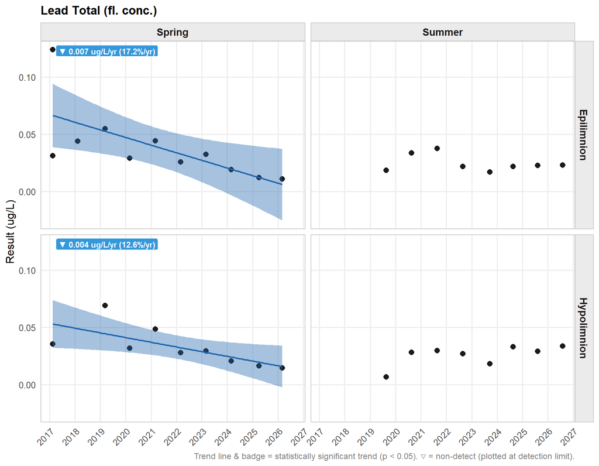

**▶ Summary Statistics Table**

**Quamichan Lake**

Lead Total (fl. conc.) (ug/L)

| N | Min<sup>1</sup> | 10th %ile | Median | Mean | 90th %ile | Max |
| --- | --- | --- | --- | --- | --- | --- |
| Hypolimnion — Summer |  |  |  |  |  |  |
| 8 | 0.0068 | 0.0148 | 0.0288 | 0.0257 | 0.0333 | 0.0337 |
| Hypolimnion — Spring |  |  |  |  |  |  |
| 9 | 0.0147 | 0.0161 | 0.0295 | 0.0327 | 0.0527 | 0.0692 |
| Epilimnion — Summer |  |  |  |  |  |  |
| 8 | 0.0167 | 0.0179 | 0.0221 | 0.0244 | 0.0347 | 0.0376 |
| Epilimnion — Spring |  |  |  |  |  |  |
| 11 | 0.0108 | 0.0121 | 0.031 | 0.0388 | 0.0547 | 0.124 |

<sup>1</sup> < indicates non-detect; value shown is the detection limit.

##### Lithium Total (fl. conc.)

—

No simple [BC Aquatic Life Guideline](https://www2.gov.bc.ca/gov/content?id=044DD64C7E24415D83D07430964113C9) available for this parameter

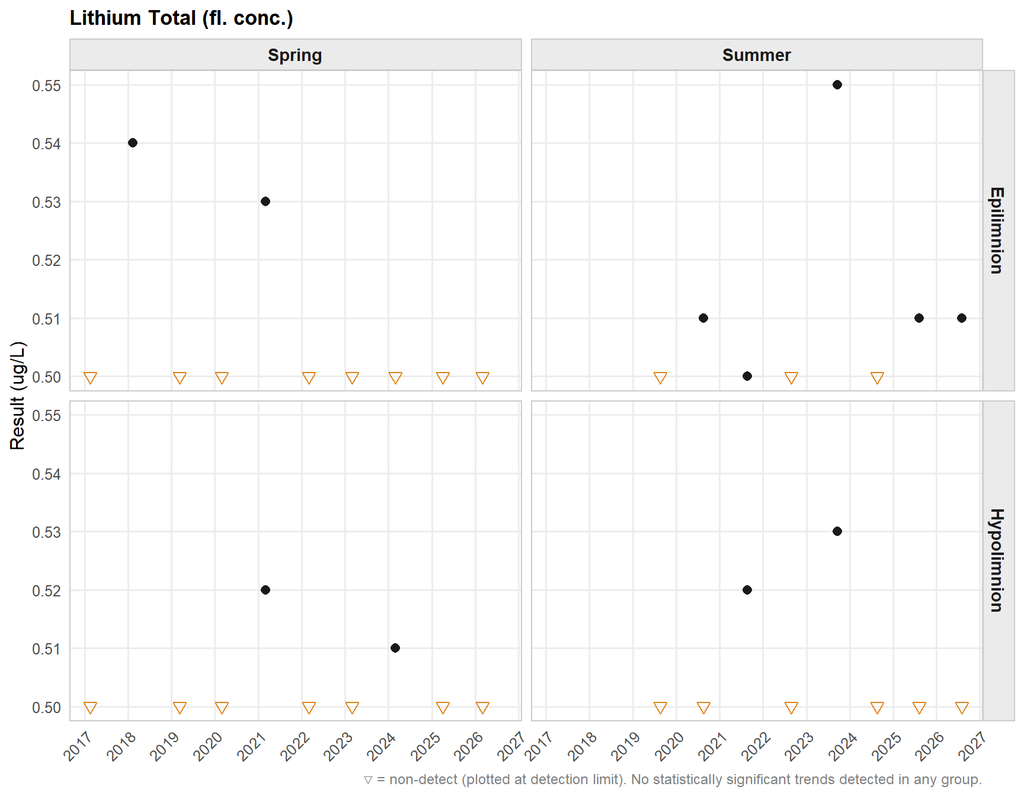

**▶ Summary Statistics Table**

**Quamichan Lake**

Lithium Total (fl. conc.) (ug/L)

| N | Min<sup>1</sup> | 10th %ile | Median | Mean | 90th %ile | Max |
| --- | --- | --- | --- | --- | --- | --- |
| Hypolimnion — Summer |  |  |  |  |  |  |
| 8 | <0.5 | <0.5 | <0.5 | 0.506 | 0.523 | 0.53 |
| Hypolimnion — Spring |  |  |  |  |  |  |
| 9 | <0.5 | <0.5 | <0.5 | 0.503 | 0.512 | 0.52 |
| Epilimnion — Summer |  |  |  |  |  |  |
| 8 | <0.5 | <0.5 | 0.505 | 0.51 | 0.522 | 0.55 |
| Epilimnion — Spring |  |  |  |  |  |  |
| 11 | <0.5 | <0.5 | <0.5 | 0.506 | 0.53 | 0.54 |

<sup>1</sup> < indicates non-detect; value shown is the detection limit.

##### Magnesium Total (fl. conc.)

—

No simple [BC Aquatic Life Guideline](https://www2.gov.bc.ca/gov/content?id=044DD64C7E24415D83D07430964113C9) available for this parameter

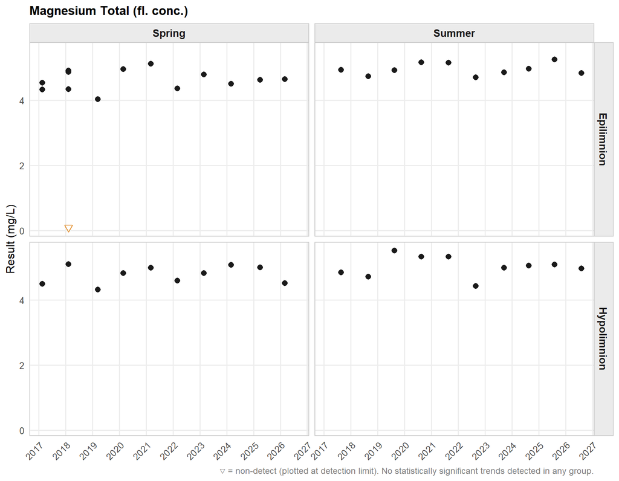

**▶ Summary Statistics Table**

**Quamichan Lake**

Magnesium Total (fl. conc.) (mg/L)

| N | Min<sup>1</sup> | 10th %ile | Median | Mean | 90th %ile | Max |
| --- | --- | --- | --- | --- | --- | --- |
| Hypolimnion — Summer |  |  |  |  |  |  |
| 10 | 4.42 | 4.68 | 5.02 | 5.02 | 5.34 | 5.51 |
| Hypolimnion — Spring |  |  |  |  |  |  |
| 10 | 4.31 | 4.47 | 4.82 | 4.77 | 5.07 | 5.09 |
| Epilimnion — Summer |  |  |  |  |  |  |
| 10 | 4.71 | 4.74 | 4.92 | 4.96 | 5.18 | 5.25 |
| Epilimnion — Spring |  |  |  |  |  |  |
| 14 | <0.1 | 4.12 | 4.58 | 4.3 | 4.94 | 5.12 |

<sup>1</sup> < indicates non-detect; value shown is the detection limit.

##### Manganese Total (fl. conc.)

—

No simple [BC Aquatic Life Guideline](https://www2.gov.bc.ca/gov/content?id=044DD64C7E24415D83D07430964113C9) available for this parameter

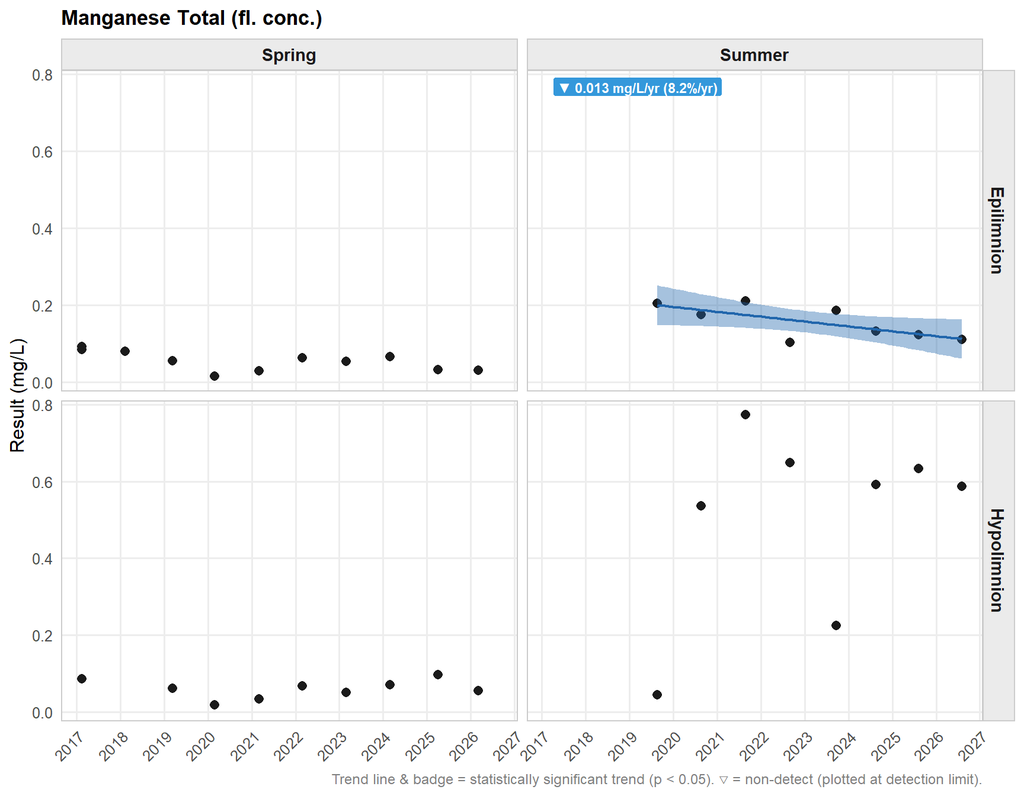

**▶ Summary Statistics Table**

**Quamichan Lake**

Manganese Total (fl. conc.) (mg/L)

| N | Min<sup>1</sup> | 10th %ile | Median | Mean | 90th %ile | Max |
| --- | --- | --- | --- | --- | --- | --- |
| Hypolimnion — Summer |  |  |  |  |  |  |
| 8 | 0.0445 | 0.171 | 0.589 | 0.505 | 0.686 | 0.773 |
| Hypolimnion — Spring |  |  |  |  |  |  |
| 9 | 0.0193 | 0.0312 | 0.0617 | 0.0603 | 0.0882 | 0.0964 |
| Epilimnion — Summer |  |  |  |  |  |  |
| 8 | 0.102 | 0.108 | 0.154 | 0.155 | 0.206 | 0.21 |
| Epilimnion — Spring |  |  |  |  |  |  |
| 11 | 0.0147 | 0.0293 | 0.0544 | 0.0544 | 0.0838 | 0.0913 |

<sup>1</sup> < indicates non-detect; value shown is the detection limit.

##### Molybdenum Total (fl. conc.)

✓

[BC Aquatic Life Guideline](https://www2.gov.bc.ca/gov/content/environment/air-land-water/water/water-quality/water-quality-guidelines/approved-water-quality-guidelines) · Long-term chronic (Upper Limit) Aquatic Life - Freshwater

≤7600 ug/L

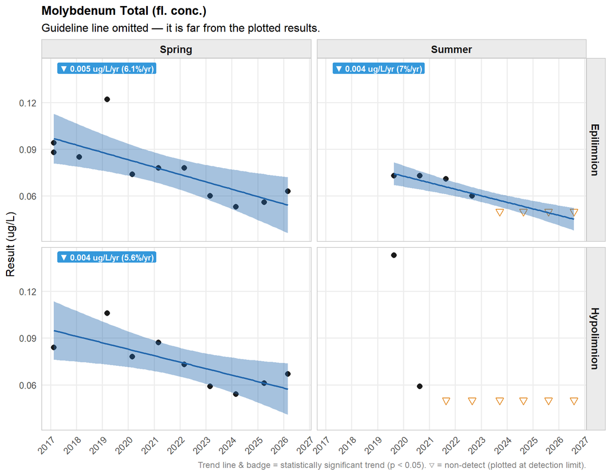

**▶ Summary Statistics Table**

**Quamichan Lake**

Molybdenum Total (fl. conc.) (ug/L)

| N | Min<sup>1</sup> | 10th %ile | Median | Mean | 90th %ile | Max |
| --- | --- | --- | --- | --- | --- | --- |
| Hypolimnion — Summer |  |  |  |  |  |  |
| 8 | <0.05 | <0.05 | <0.05 | 0.0628 | 0.0842 | 0.143 |
| Hypolimnion — Spring |  |  |  |  |  |  |
| 9 | 0.054 | 0.058 | 0.073 | 0.0743 | 0.0908 | 0.106 |
| Epilimnion — Summer |  |  |  |  |  |  |
| 8 | <0.05 | <0.05 | 0.055 | 0.0596 | 0.073 | 0.073 |
| Epilimnion — Spring |  |  |  |  |  |  |
| 11 | 0.053 | 0.056 | 0.078 | 0.0774 | 0.094 | 0.122 |

<sup>1</sup> < indicates non-detect; value shown is the detection limit.

##### Nickel Total (fl. conc.)

—

No simple [BC Aquatic Life Guideline](https://www2.gov.bc.ca/gov/content?id=044DD64C7E24415D83D07430964113C9) available for this parameter

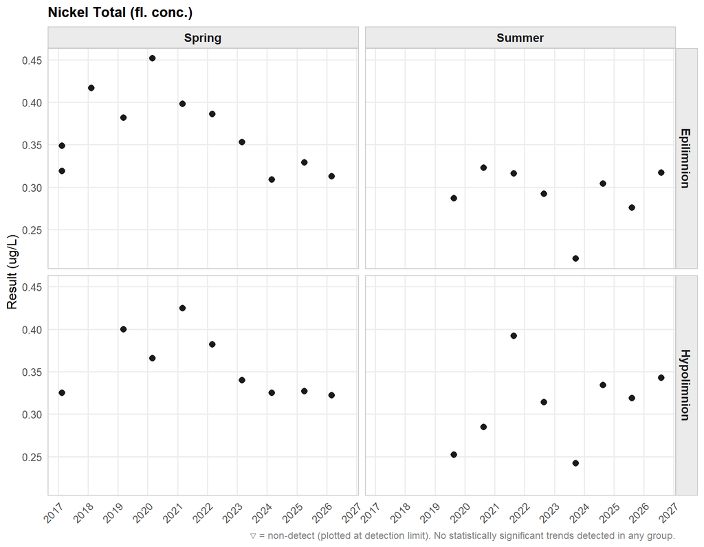

**▶ Summary Statistics Table**

**Quamichan Lake**

Nickel Total (fl. conc.) (ug/L)

| N | Min<sup>1</sup> | 10th %ile | Median | Mean | 90th %ile | Max |
| --- | --- | --- | --- | --- | --- | --- |
| Hypolimnion — Summer |  |  |  |  |  |  |
| 8 | 0.242 | 0.249 | 0.316 | 0.31 | 0.358 | 0.392 |
| Hypolimnion — Spring |  |  |  |  |  |  |
| 9 | 0.322 | 0.324 | 0.34 | 0.357 | 0.405 | 0.425 |
| Epilimnion — Summer |  |  |  |  |  |  |
| 8 | 0.216 | 0.258 | 0.298 | 0.291 | 0.319 | 0.323 |
| Epilimnion — Spring |  |  |  |  |  |  |
| 11 | 0.309 | 0.313 | 0.353 | 0.364 | 0.417 | 0.452 |

<sup>1</sup> < indicates non-detect; value shown is the detection limit.

##### Potassium Total (fl. conc.)

—

No simple [BC Aquatic Life Guideline](https://www2.gov.bc.ca/gov/content?id=044DD64C7E24415D83D07430964113C9) available for this parameter

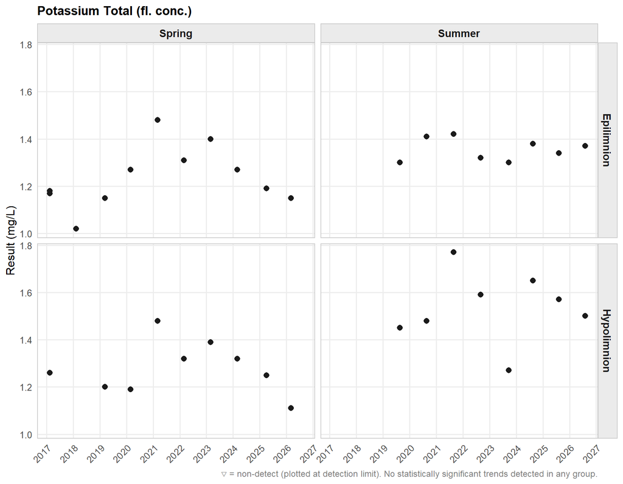

**▶ Summary Statistics Table**

**Quamichan Lake**

Potassium Total (fl. conc.) (mg/L)

| N | Min<sup>1</sup> | 10th %ile | Median | Mean | 90th %ile | Max |
| --- | --- | --- | --- | --- | --- | --- |
| Hypolimnion — Summer |  |  |  |  |  |  |
| 8 | 1.27 | 1.4 | 1.54 | 1.54 | 1.69 | 1.77 |
| Hypolimnion — Spring |  |  |  |  |  |  |
| 9 | 1.11 | 1.17 | 1.26 | 1.28 | 1.41 | 1.48 |
| Epilimnion — Summer |  |  |  |  |  |  |
| 8 | 1.3 | 1.3 | 1.36 | 1.36 | 1.41 | 1.42 |
| Epilimnion — Spring |  |  |  |  |  |  |
| 11 | 1.02 | 1.15 | 1.19 | 1.24 | 1.4 | 1.48 |

<sup>1</sup> < indicates non-detect; value shown is the detection limit.

##### Selenium Total (fl. conc.)

⚠

[BC Aquatic Life Guideline](https://www2.gov.bc.ca/gov/content/environment/air-land-water/water/water-quality/water-quality-guidelines/approved-water-quality-guidelines) · Long-term chronic (Upper Limit) Aquatic Life - Freshwater

≤2 ug/L

[figure not shown]

**▶ Summary Statistics Table**

**Quamichan Lake**

Selenium Total (fl. conc.) (ug/L)

| N | Min<sup>1</sup> | 10th %ile | Median | Mean | 90th %ile | Max<sup>2</sup> |
| --- | --- | --- | --- | --- | --- | --- |
| Hypolimnion — Summer |  |  |  |  |  |  |
| 8 | 0.1 | 0.134 | 0.388 | 0.762 | 2 | 2.53 |
| Hypolimnion — Spring |  |  |  |  |  |  |
| 9 | 0.103 | 0.125 | 0.152 | 0.15 | 0.176 | 0.184 |
| Epilimnion — Summer |  |  |  |  |  |  |
| 8 | 0.078 | 0.0801 | 0.1 | 0.102 | 0.123 | 0.152 |
| Epilimnion — Spring |  |  |  |  |  |  |
| 11 | 0.12 | 0.129 | 0.151 | 0.158 | 0.201 | 0.222 |

<sup>1</sup> < indicates non-detect; value shown is the detection limit.  
<sup>2</sup> Red = this group’s maximum result exceeds the BC Aquatic Life guideline.

##### Silicon Total (fl. conc.)

—

No simple [BC Aquatic Life Guideline](https://www2.gov.bc.ca/gov/content?id=044DD64C7E24415D83D07430964113C9) available for this parameter

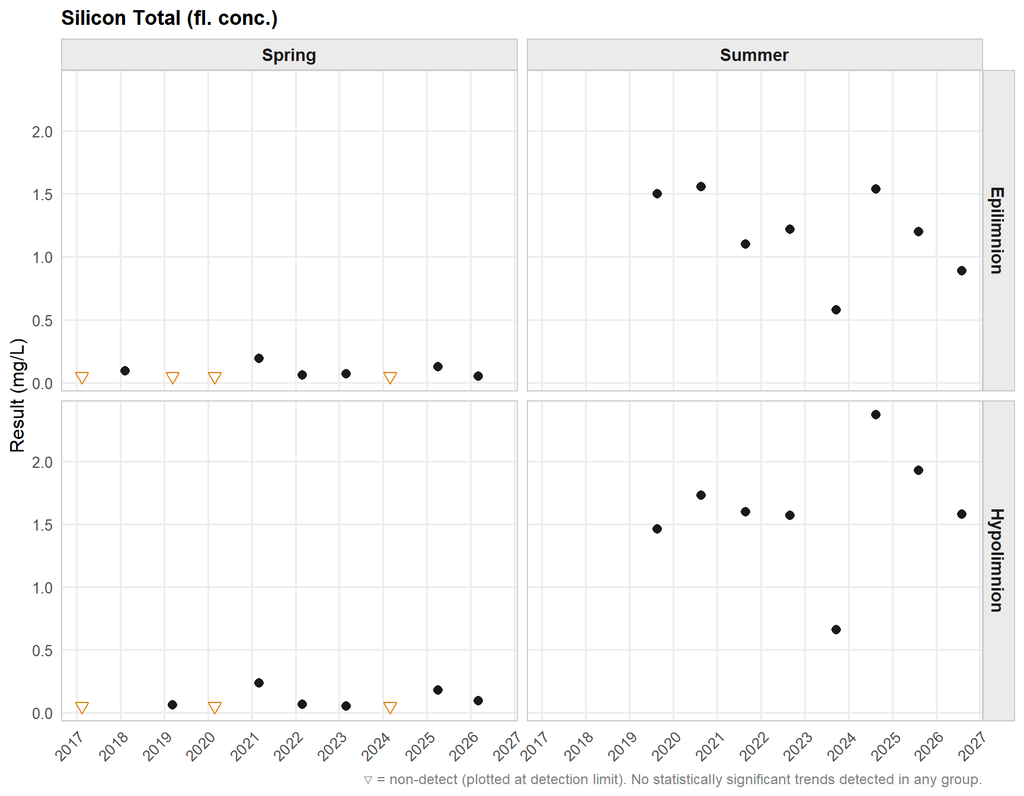

**▶ Summary Statistics Table**

**Quamichan Lake**

Silicon Total (fl. conc.) (mg/L)

| N | Min<sup>1</sup> | 10th %ile | Median | Mean | 90th %ile | Max |
| --- | --- | --- | --- | --- | --- | --- |
| Hypolimnion — Summer |  |  |  |  |  |  |
| 8 | 0.662 | 1.22 | 1.59 | 1.61 | 2.06 | 2.37 |
| Hypolimnion — Spring |  |  |  |  |  |  |
| 9 | <0.05 | <0.05 | 0.06 | 0.0931 | 0.192 | 0.236 |
| Epilimnion — Summer |  |  |  |  |  |  |
| 8 | 0.579 | 0.795 | 1.21 | 1.2 | 1.55 | 1.56 |
| Epilimnion — Spring |  |  |  |  |  |  |
| 11 | <0.05 | <0.05 | 0.052 | 0.0761 | 0.125 | 0.19 |

<sup>1</sup> < indicates non-detect; value shown is the detection limit.

##### Silver Total (fl. conc.)

✓

[BC Aquatic Life Guideline](https://www2.gov.bc.ca/gov/content/environment/air-land-water/water/water-quality/water-quality-guidelines/approved-water-quality-guidelines) · Long-term chronic (Upper Limit) Aquatic Life - Freshwater

≤120 ng/L

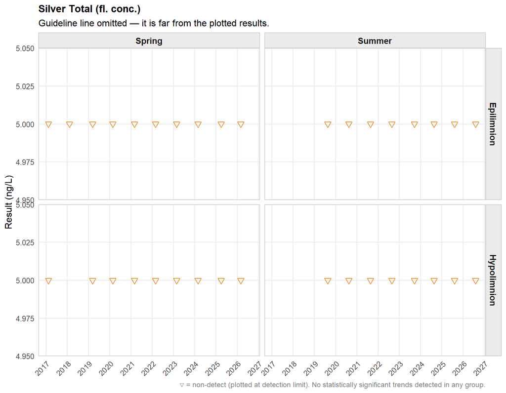

**▶ Summary Statistics Table**

**Quamichan Lake**

Silver Total (fl. conc.) (ng/L)

| N | Min<sup>1</sup> | 10th %ile | Median | Mean | 90th %ile | Max |
| --- | --- | --- | --- | --- | --- | --- |
| Hypolimnion — Summer |  |  |  |  |  |  |
| 8 | <5 | <5 | <5 | <5 | <5 | <5 |
| Hypolimnion — Spring |  |  |  |  |  |  |
| 9 | <5 | <5 | <5 | <5 | <5 | <5 |
| Epilimnion — Summer |  |  |  |  |  |  |
| 8 | <5 | <5 | <5 | <5 | <5 | <5 |
| Epilimnion — Spring |  |  |  |  |  |  |
| 11 | <5 | <5 | <5 | <5 | <5 | <5 |

<sup>1</sup> < indicates non-detect; value shown is the detection limit.

##### Sodium Total (fl. conc.)

—

No simple [BC Aquatic Life Guideline](https://www2.gov.bc.ca/gov/content?id=044DD64C7E24415D83D07430964113C9) available for this parameter

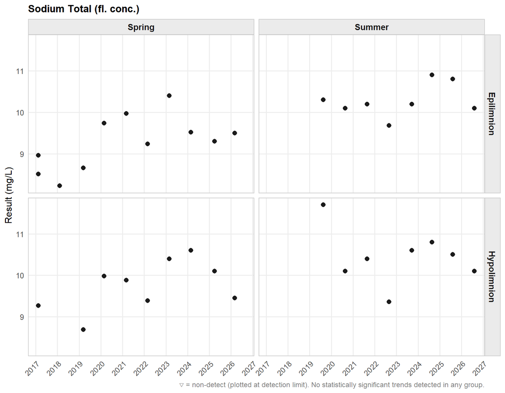

**▶ Summary Statistics Table**

**Quamichan Lake**

Sodium Total (fl. conc.) (mg/L)

| N | Min<sup>1</sup> | 10th %ile | Median | Mean | 90th %ile | Max |
| --- | --- | --- | --- | --- | --- | --- |
| Hypolimnion — Summer |  |  |  |  |  |  |
| 8 | 9.36 | 9.88 | 10.4 | 10.4 | 11.1 | 11.7 |
| Hypolimnion — Spring |  |  |  |  |  |  |
| 9 | 8.69 | 9.15 | 9.88 | 9.75 | 10.4 | 10.6 |
| Epilimnion — Summer |  |  |  |  |  |  |
| 8 | 9.68 | 9.97 | 10.2 | 10.3 | 10.8 | 10.9 |
| Epilimnion — Spring |  |  |  |  |  |  |
| 11 | 8.23 | 8.51 | 9.3 | 9.28 | 9.97 | 10.4 |

<sup>1</sup> < indicates non-detect; value shown is the detection limit.

##### Strontium Total (fl. conc.)

—

No simple [BC Aquatic Life Guideline](https://www2.gov.bc.ca/gov/content?id=044DD64C7E24415D83D07430964113C9) available for this parameter

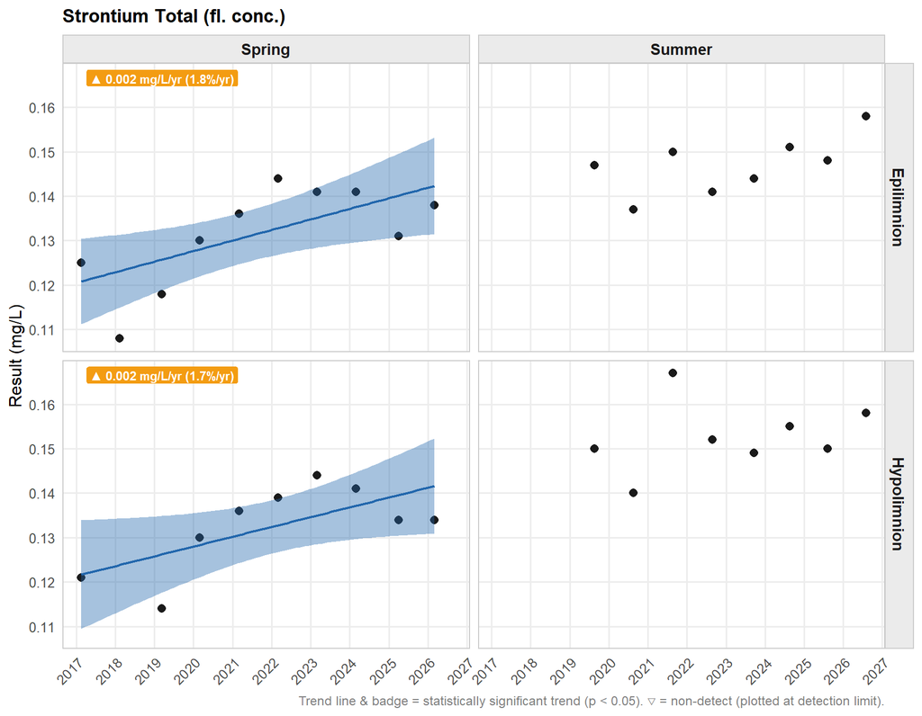

**▶ Summary Statistics Table**

**Quamichan Lake**

Strontium Total (fl. conc.) (mg/L)

| N | Min<sup>1</sup> | 10th %ile | Median | Mean | 90th %ile | Max |
| --- | --- | --- | --- | --- | --- | --- |
| Hypolimnion — Summer |  |  |  |  |  |  |
| 8 | 0.14 | 0.146 | 0.151 | 0.153 | 0.161 | 0.167 |
| Hypolimnion — Spring |  |  |  |  |  |  |
| 9 | 0.114 | 0.12 | 0.134 | 0.133 | 0.142 | 0.144 |
| Epilimnion — Summer |  |  |  |  |  |  |
| 8 | 0.137 | 0.14 | 0.148 | 0.147 | 0.153 | 0.158 |
| Epilimnion — Spring |  |  |  |  |  |  |
| 11 | 0.108 | 0.118 | 0.131 | 0.131 | 0.141 | 0.144 |

<sup>1</sup> < indicates non-detect; value shown is the detection limit.

##### Thallium Total (fl. conc.)

✓

[BC Aquatic Life Guideline](https://www2.gov.bc.ca/gov/content/environment/air-land-water/water/water-quality/water-quality-guidelines/approved-water-quality-guidelines) · Long-term chronic (Upper Limit) Aquatic Life - Freshwater

≤30 ng/L

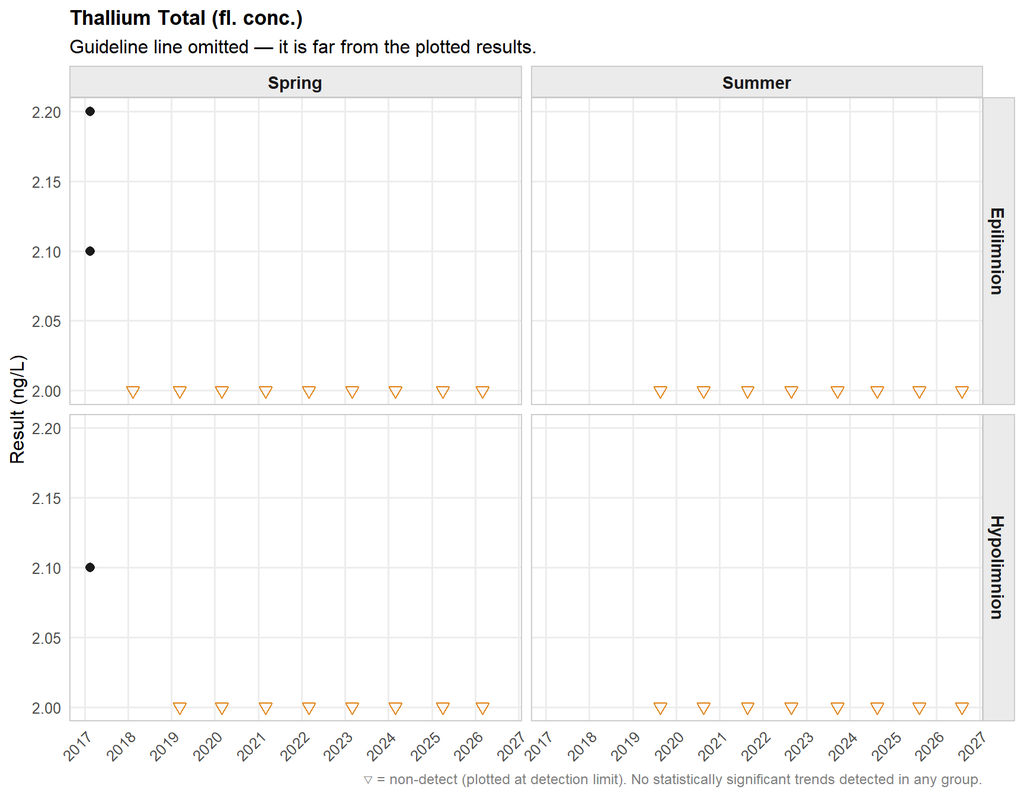

**▶ Summary Statistics Table**

**Quamichan Lake**

Thallium Total (fl. conc.) (ng/L)

| N | Min<sup>1</sup> | 10th %ile | Median | Mean | 90th %ile | Max |
| --- | --- | --- | --- | --- | --- | --- |
| Hypolimnion — Summer |  |  |  |  |  |  |
| 8 | <2 | <2 | <2 | <2 | <2 | <2 |
| Hypolimnion — Spring |  |  |  |  |  |  |
| 9 | <2 | <2 | <2 | 2.01 | 2.02 | 2.1 |
| Epilimnion — Summer |  |  |  |  |  |  |
| 8 | <2 | <2 | <2 | <2 | <2 | <2 |
| Epilimnion — Spring |  |  |  |  |  |  |
| 11 | <2 | <2 | <2 | 2.03 | 2.1 | 2.2 |

<sup>1</sup> < indicates non-detect; value shown is the detection limit.

##### Tin Total (fl. conc.)

—

No simple [BC Aquatic Life Guideline](https://www2.gov.bc.ca/gov/content?id=044DD64C7E24415D83D07430964113C9) available for this parameter

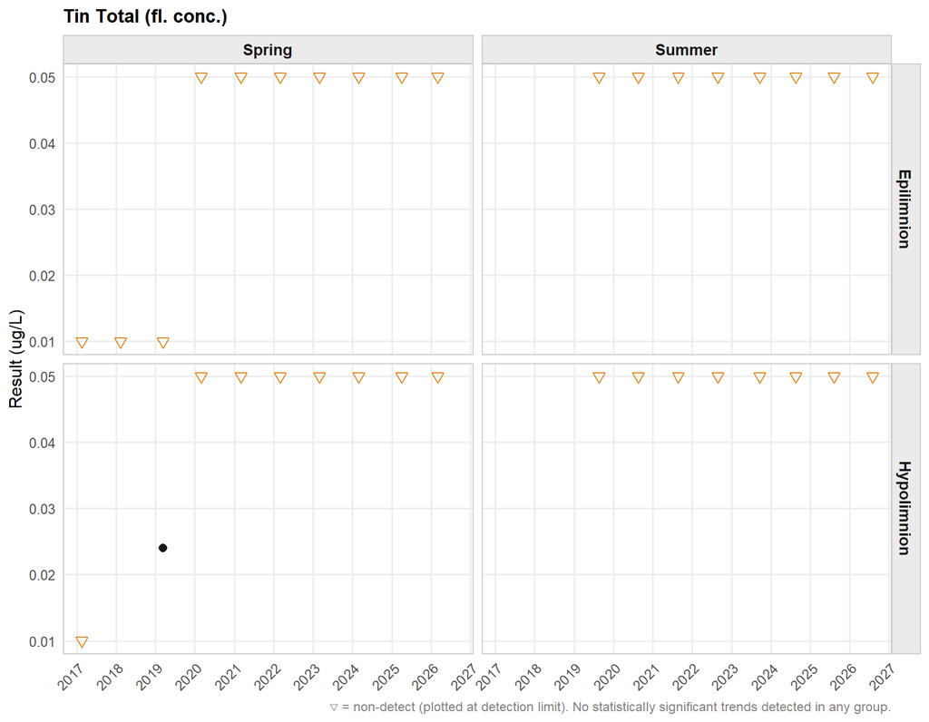

**▶ Summary Statistics Table**

**Quamichan Lake**

Tin Total (fl. conc.) (ug/L)

[output not shown]

<sup>1</sup> < indicates non-detect; value shown is the detection limit.

##### Uranium Total (fl. conc.)

✓

[BC Aquatic Life Guideline](https://www2.gov.bc.ca/gov/content/environment/air-land-water/water/water-quality/water-quality-guidelines/approved-water-quality-guidelines) · Long-term chronic (Upper Limit) Aquatic Life - Freshwater

≤7500 ng/L

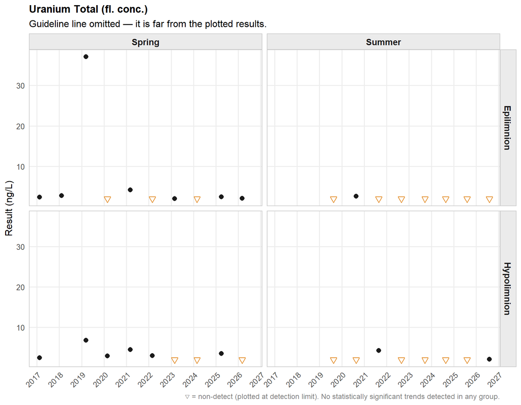

**▶ Summary Statistics Table**

**Quamichan Lake**

Uranium Total (fl. conc.) (ng/L)

| N | Min<sup>1</sup> | 10th %ile | Median | Mean | 90th %ile | Max |
| --- | --- | --- | --- | --- | --- | --- |
| Hypolimnion — Summer |  |  |  |  |  |  |
| 8 | <2 | <2 | <2 | 2.3 | 2.76 | 4.3 |
| Hypolimnion — Spring |  |  |  |  |  |  |
| 9 | <2 | <2 | 2.9 | 3.24 | 4.96 | 6.8 |
| Epilimnion — Summer |  |  |  |  |  |  |
| 8 | <2 | <2 | <2 | 2.08 | 2.18 | 2.6 |
| Epilimnion — Spring |  |  |  |  |  |  |
| 11 | <2 | <2 | 2.4 | 5.59 | 4.2 | 37.1 |

<sup>1</sup> < indicates non-detect; value shown is the detection limit.

##### Vanadium Total (fl. conc.)

✓

[BC Aquatic Life Guideline](https://www2.gov.bc.ca/gov/content/environment/air-land-water/water/water-quality/water-quality-guidelines/approved-water-quality-guidelines) · Long-term chronic (Upper Limit) Aquatic Life - Freshwater

≤60 ug/L

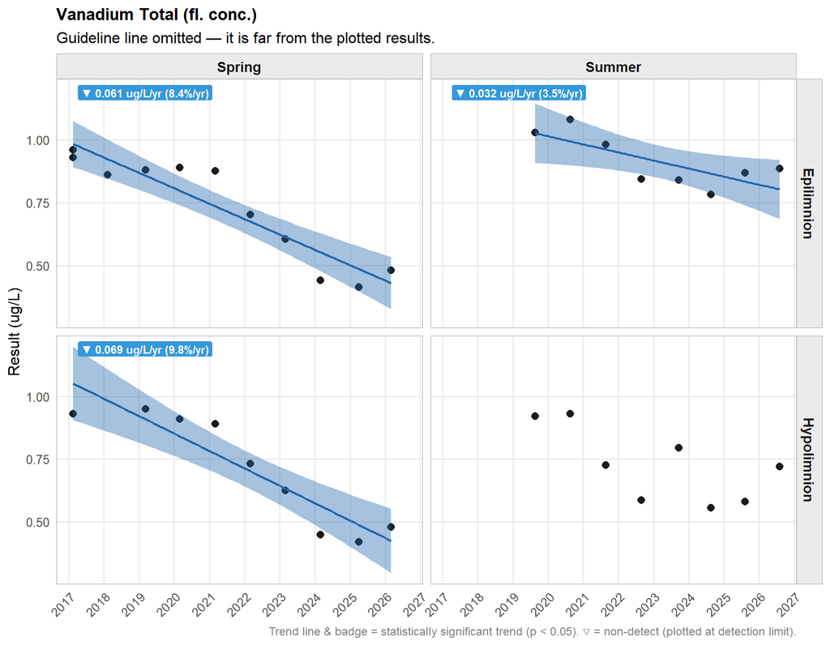

**▶ Summary Statistics Table**

**Quamichan Lake**

Vanadium Total (fl. conc.) (ug/L)

| N | Min<sup>1</sup> | 10th %ile | Median | Mean | 90th %ile | Max |
| --- | --- | --- | --- | --- | --- | --- |
| Hypolimnion — Summer |  |  |  |  |  |  |
| 8 | 0.556 | 0.574 | 0.724 | 0.727 | 0.923 | 0.93 |
| Hypolimnion — Spring |  |  |  |  |  |  |
| 9 | 0.42 | 0.442 | 0.732 | 0.709 | 0.934 | 0.95 |
| Epilimnion — Summer |  |  |  |  |  |  |
| 8 | 0.782 | 0.822 | 0.878 | 0.914 | 1.04 | 1.08 |
| Epilimnion — Spring |  |  |  |  |  |  |
| 11 | 0.414 | 0.441 | 0.86 | 0.731 | 0.93 | 0.96 |

<sup>1</sup> < indicates non-detect; value shown is the detection limit.

##### Zinc Total (fl. conc.)

—

No simple [BC Aquatic Life Guideline](https://www2.gov.bc.ca/gov/content?id=044DD64C7E24415D83D07430964113C9) available for this parameter

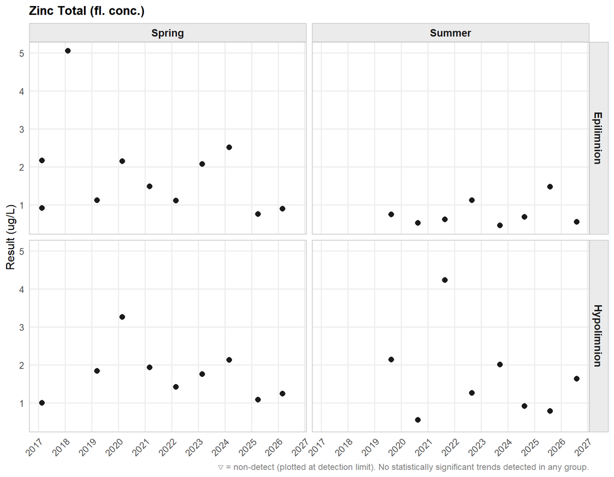

**▶ Summary Statistics Table**

**Quamichan Lake**

Zinc Total (fl. conc.) (ug/L)

| N | Min<sup>1</sup> | 10th %ile | Median | Mean | 90th %ile | Max |
| --- | --- | --- | --- | --- | --- | --- |
| Hypolimnion — Summer |  |  |  |  |  |  |
| 8 | 0.55 | 0.711 | 1.44 | 1.69 | 2.77 | 4.23 |
| Hypolimnion — Spring |  |  |  |  |  |  |
| 9 | 1 | 1.06 | 1.75 | 1.74 | 2.36 | 3.26 |
| Epilimnion — Summer |  |  |  |  |  |  |
| 8 | 0.46 | 0.509 | 0.65 | 0.774 | 1.23 | 1.48 |
| Epilimnion — Spring |  |  |  |  |  |  |
| 11 | 0.76 | 0.9 | 1.49 | 1.84 | 2.52 | 5.06 |

<sup>1</sup> < indicates non-detect; value shown is the detection limit.

### Disclaimer

This document was produced by an automated system and has not necessarily gone through quality control checks. It is presented “as-is” with no guarantee of accuracy or completeness. Read our full [Disclaimer](https://www2.gov.bc.ca/gov/content?id=79F93E018712422FBC8E674A67A70535) for more information.